# Concept of Data Mining

[figure not shown]

# Data Mining

- 대량의 데이터로부터 새롭고 의미 있는 정보를 추출하여 의사결정에 활용하는 작업
  - 지식발견
  - 정보발견, 정보수학
  - 정보고고학, 자료패턴처리

## 데이터마이닝의 다양한 정의

- 데이터베이스에서 지기발견은 데이터에 있는 유효하고, 잠재적으로 이용가능하며 궁극적으로 이해할 수 있는 패턴을 식별하는 중요한 프로세스 (Fayyad et al., “Advance in Knowledge Discovery and Data Mining,”1996)
- 데이터 마이닝은 비즈니스 문제를 해결하기 위해 현재 조치를 취할 수 있고,명시적이며 새로운 정보를 추출하기 위해 세부적인 데이터를 분석하는 프로세스이다.(NCR)
- 데이터 마이닝은 큰 데이터베이스로부터 이전에 알려지지 않고, 궁극적으로이해가능한 정보를 추출 및 중요한 비즈니스 의사결정을 하는 프로세스이다.(IBM)
- 데이터 마이닝은 비즈니스 우위를 위해 이전에 알려지지 않은 패턴을 발견하기 위해 많은 양의 데이터를 선택하고, 탐색 및 모델링하는 프로세스이다.(SAS Institute)
- 데이터 마이닝은 기업의 경영 활동에서 발생하는 대용량 데이터에서 데이터간의 관계·패턴·규칙 등을 찾아내고 모형화해 유용한 경영 정보로 변환시키는 일련의 과정이다.

## Statistics Vs DM

- 전통적 통계분석
  - 대상집단이 있으며, 모집단의 분포 혹은 모형 등 여러 가지 가정을 전제로 하게 되며 이 전제 조건하에서 분석을 실시
  - **=>표본의 관찰을 통해 모수 전체를 추론하는 과정**
- 데이터마이닝
  - 표본조사/실험에서 필연적으로 수반되는 분포라든가 모형에 대한 전제조건이 필요하지않음
  - **=>모집단의 전체자료를 이용한 정보화하는 과정**

## SQL / OLAP / DataMining

[figure not shown]

## What Problems can DM Solve ?

- 대부분의 문제에 대해서 결과를 예측한다. 또는 확률, 의사결정, 수치를 에측한다.

# Data Mining Process

[figure not shown]

# Predictive Modeling Process

[figure not shown]

# 데이터마이닝 기법의 종류

## Supervised Modeling (지도 학습, Predictive Analytics)

- Estimation / Prediction (추정/예측 : 연속형)
  - Linear Regression, Neural Network
- Classification / Prediction (분류/예측 : 이산형)
  - Decision Tree(C5.0), Neural Network, SVM

  <font size=3 color='green'>용어의 유례 : 어리아이가 말을 배우는 과정 ( 엄마가 Supervisor ) </font>

## unsupervised Modeling ( 비지도 학습 , descriptive Analytics)

- Clustering(군집화)
  - K-Means, SOM
- Association rule Mining ( 연관규칙 탐사 )
- Sequential rule Mining ( 연속규칙 탐사 )

## 1. 연관 규칙 탐사 (Association Rule Mining)

- 정의
  - 데이터 안에 존재하는 항목간의 종속 관계를 찾아내는 작업
- 장바구니 분석(Market Basket Analysis)
  - 고객의 장바구니에 들어있는 품목 간의 관계를 발견
- 규칙의 표현
  - 항목 A와 품목 B를 구매한 고객은 품목 C를 구매한다.
  - (품목A) & (품목B) => (품목C)
- 연관규칙의 활용
  - 제품이나 서비스의 교차 판매
  - 매장진열, 첨부우편
  - 사기적발

[figure not shown]

## 2. 연속규칙탐사 ( Sequential Rule Mining )

- 정의
  - 연관 규칙에 시간 관련 정보가 포함된 형태
- 규칙의 표현
  - 새 냉장고를 구입한 고객 중 한달 이내에 새 오븐을 구입하는 경향이 많다.
- 연속 규칙의 활용
  - 타겟 마케팅
  - 일대일 마케팅
- 전제조건
  - 고객의 구매내역(History) 정보가 반드시 필요함.

[figure not shown]

## 3. 분류 ( Classification )

- 분류 프로세스
  - 과거의 데이터를 부류로 구분
  - 부류별 특성을 발견
  - 분류 모형 생성
  - 모형을 토대로 새로운 레코드의 분류 값 예측
- 분류의 활용
  - 고객의 신용등급 분류
  - 기업의 도산 예측
  - 프로모션 대상고객 선정
- 분류 기법
  - 의사결정나무 (Decision Tree)
  - 인공신경망 (Neural Network)
  - SVM(Support Vector Machine)

[figure not shown]

## 4. 군집화(Clustering)

- 정의
  - 레코드들을 유사한 특성을 지닌 몇 개의 소그룹으로 분할하는 작업
- 군집화의 활용
  - 다른 데이터 마이닝 기법의 선행 작업으로써 많이 이용
- 분류 vs 군집화
  - 분류 값의 유무
- 군집화 기법
  - 계층적 군집분석
  - 비계층적 군집분석: K-means, EM Algorithm, SOM(Self-Organizing Map)

[figure not shown]

## 데이터 분할(Data Partitioning)

[figure not shown]

### 5 Folder Cross Validation

| 1 | 2 | 3 | 4 | 5 |
| --- | --- | --- | --- | --- |
| A | B | C | D | E |

```
                            - ABCD : 학습 , E : 검증
                            - BCDE : 학습 , A : 검증
                              와 같은 방법으로 5가지의 경우의 수를 모두 입력
```

# Data Mining Demo

## 1. Business Understanding

> 한 은행이 새로운 개인연금상품(PEP)을 신설하여 기존 고객들을 대상으로 가능한 많은 계좌를 유치하고자 한다.

> 고객의금융상품(PEP: Personal Equity Plan, 연금보험) 구매여부 예측에 의한 신규고객 창출
> - 고객 프로파일 개발
> - 다이렉트 메일 광고 효율성 제고
> - 타겟 메일링에 의한 응답률 제고

> 분석 절차
> - 1) 기존 고객 DB로부터 시험 메일 발송을 위한 표본 고객 목록을 추출
> - 2) 새로운금융상품(PEP)의 제안 메일을 발송
> - 3) 고객의 반응을 기록
> - 4) R을 이용하여 캠페인 결과를 분석

## 2. Data Understanding

> 학습용 데이터 300건 (pepTrainSet.csv)

> 신규 고객 데이터 200건 (pepNewCustomers.csv)

## 3. Data Preparation

```r
train <- read.csv("pepTrainSet.csv", stringsAsFactors=F)
train <- subset(train, select=-c(id))
test <- read.csv("pepTestSet.csv", stringsAsFactors=F)
newd <- read.csv("pepNewCustomers.csv", stringsAsFactors=F)

train$pep <- factor(train$pep)
test$pep <- factor(test$pep)

str(train)
```

```
'data.frame':	300 obs. of  11 variables:
 $ age        : int  48 40 51 23 57 57 22 58 37 54 ...
 $ sex        : chr  "FEMALE" "MALE" "FEMALE" "FEMALE" ...
 $ region     : chr  "INNER_CITY" "TOWN" "INNER_CITY" "TOWN" ...
 $ income     : num  17546 30085 16575 20375 50576 ...
 $ married    : chr  "NO" "YES" "YES" "YES" ...
 $ children   : int  1 3 0 3 0 2 0 0 2 2 ...
 $ car        : chr  "NO" "YES" "YES" "NO" ...
 $ save_act   : chr  "NO" "NO" "YES" "NO" ...
 $ current_act: chr  "NO" "YES" "YES" "YES" ...
 $ mortgage   : chr  "NO" "YES" "NO" "NO" ...
 $ pep        : Factor w/ 2 levels "NO","YES": 2 1 1 1 1 2 2 1 1 1 ...
```

## 4. Modeling(Cont.)

```r
install.packages("caret",repos = "http://cran.us.r-project.org") #데이너 전처리 / 모델
install.packages("ROCR",repos = "http://cran.us.r-project.org") # 모형의 그래프 생성과 평가
install.packages("C50",repos = "http://cran.us.r-project.org") # 분류 분석, 의사결정나무 (Decision Tree)
```

```r
library(caret)
library(ROCR)
library(C50)
```

```r
?C5.0Control
```

### first candidate model : Decision Tree(C5.0)

```r
c5_options <- C5.0Control(winnow = FALSE, noGlobalPruning = FALSE)
c5_model <- C5.0(pep ~ ., data=train, control=c5_options, rules=FALSE)
summary(c5_model)
```

```
Call:
C5.0.formula(formula = pep ~ ., data = train, control = c5_options, rules
 = FALSE)


C5.0 [Release 2.07 GPL Edition]  	Sat Sep 10 23:23:12 2016
-------------------------------

Class specified by attribute `outcome'

Read 300 cases (11 attributes) from undefined.data

Decision tree:

children > 2:
:...income <= 43228.2: NO (30/2)
:   income > 43228.2: YES (5)
children <= 2:
:...children <= 0:
    :...married = NO:
    :   :...mortgage = NO: YES (29/2)
    :   :   mortgage = YES:
    :   :   :...save_act = NO: YES (3)
    :   :       save_act = YES: NO (12)
    :   married = YES:
    :   :...mortgage = NO: NO (59/6)
    :       mortgage = YES:
    :       :...save_act = NO: YES (9/1)
    :           save_act = YES: NO (16/2)
    children > 0:
    :...income > 29622: YES (48/2)
        income <= 29622:
        :...children > 1: NO (47/3)
            children <= 1:
            :...income <= 12640.3: NO (5)
                income > 12640.3:
                :...current_act = YES: YES (28/1)
                    current_act = NO:
                    :...income <= 17390.1: NO (3)
                        income > 17390.1: YES (6)
```

[output cut: 13 more lines]

```
	   159     6    (a): class NO
	    13   122    (b): class YES


	Attribute usage:

	100.00%	children
	 57.33%	income
	 42.67%	married
	 42.67%	mortgage
	 13.33%	save_act
	 12.33%	current_act


Time: 0.0 secs
```

```r
## plot(c5_model, cex=1.0)
# 결과가 그림으로 찌그러져 나온다.
```

[figure not shown]

[figure not shown]

```r
plot(c5_model, cex=1.0)
```

### Second candidate model : Logistic Regression

```r
lm_model <- glm(pep~.,data=train,family=binomial)
summary(lm_model)
```

```
Call:
glm(formula = pep ~ ., family = binomial, data = train)

Deviance Residuals:
    Min       1Q   Median       3Q      Max
-2.1618  -0.9717  -0.6610   1.0941   2.0354

Coefficients:
                 Estimate Std. Error z value Pr(>|z|)
(Intercept)    -1.568e+00  5.666e-01  -2.767  0.00565 **
age             1.593e-02  1.299e-02   1.227  0.21998
sexMALE         6.887e-01  2.583e-01   2.666  0.00768 **
regionRURAL     2.696e-01  3.702e-01   0.728  0.46641
regionSUBURBAN -4.920e-02  4.905e-01  -0.100  0.92011
regionTOWN     -1.790e-01  2.960e-01  -0.605  0.54541
income          3.863e-05  1.518e-05   2.545  0.01093 *
marriedYES     -6.382e-01  2.679e-01  -2.382  0.01720 *
children       -1.800e-01  1.195e-01  -1.506  0.13200
carYES         -2.357e-01  2.535e-01  -0.930  0.35241
save_actYES    -3.225e-01  2.786e-01  -1.158  0.24696
current_actYES  3.680e-01  3.159e-01   1.165  0.24401
mortgageYES    -1.942e-01  2.696e-01  -0.720  0.47128
---
Signif. codes:  0 '***' 0.001 '**' 0.01 '*' 0.05 '.' 0.1 ' ' 1

(Dispersion parameter for binomial family taken to be 1)

    Null deviance: 412.88  on 299  degrees of freedom
Residual deviance: 370.64  on 287  degrees of freedom
AIC: 396.64

Number of Fisher Scoring iterations: 4
```

### Model evaluation by Confusion Matrix

```r
install.packages("e1071",repos = "http://cran.us.r-project.org")
```

```r
library(e1071)
```

```r
test$c5_pred <- predict(c5_model, test, type="class")
test$c5_pred_prob <- predict(c5_model, test, type="prob")
head(test)
str(test)
```

|  | id | age | sex | region | income | married | children | car | save_act | current_act | mortgage | pep | c5_pred | c5_pred_prob |  |
| --- | --- | --- | --- | --- | --- | --- | --- | --- | --- | --- | --- | --- | --- | --- | --- |
| 1 | ID12401 | 19 | FEMALE | INNER_CITY | 8162.42 | YES | 1 | YES | YES | YES | YES | NO | NO | 0.925000001986822 | 0.0749999980131785 |
| 2 | ID12402 | 37 | FEMALE | TOWN | 15349.6 | YES | 0 | NO | YES | NO | NO | NO | NO | 0.892500000525266 | 0.107499999474734 |
| 3 | ID12403 | 45 | FEMALE | TOWN | 29231.4 | YES | 0 | NO | YES | NO | NO | NO | NO | 0.892500000525266 | 0.107499999474734 |
| 4 | ID12404 | 49 | MALE | RURAL | 41462.3 | YES | 3 | NO | YES | YES | YES | NO | NO | 0.920967739525093 | 0.0790322604749069 |
| 5 | ID12405 | 67 | FEMALE | RURAL | 57398.1 | NO | 3 | NO | YES | YES | NO | YES | YES | 0.0916666686534882 | 0.908333331346512 |
| 6 | ID12406 | 35 | FEMALE | RURAL | 11520.8 | YES | 0 | NO | NO | YES | NO | NO | NO | 0.892500000525266 | 0.107499999474734 |

```
'data.frame':	300 obs. of  14 variables:
 $ id          : chr  "ID12401" "ID12402" "ID12403" "ID12404" ...
 $ age         : int  19 37 45 49 67 35 63 38 48 28 ...
 $ sex         : chr  "FEMALE" "FEMALE" "FEMALE" "MALE" ...
 $ region      : chr  "INNER_CITY" "TOWN" "TOWN" "RURAL" ...
 $ income      : num  8162 15350 29231 41462 57398 ...
 $ married     : chr  "YES" "YES" "YES" "YES" ...
 $ children    : int  1 0 0 3 3 0 2 0 2 1 ...
 $ car         : chr  "YES" "NO" "NO" "NO" ...
 $ save_act    : chr  "YES" "YES" "YES" "YES" ...
 $ current_act : chr  "YES" "NO" "NO" "YES" ...
 $ mortgage    : chr  "YES" "NO" "NO" "YES" ...
 $ pep         : Factor w/ 2 levels "NO","YES": 1 1 1 1 2 1 2 2 1 1 ...
 $ c5_pred     : Factor w/ 2 levels "NO","YES": 1 1 1 1 2 1 2 2 1 1 ...
 $ c5_pred_prob: num [1:300, 1:2] 0.925 0.8925 0.8925 0.921 0.0917 ...
  ..- attr(*, "dimnames")=List of 2
  .. ..$ : chr  "1" "2" "3" "4" ...
  .. ..$ : chr  "NO" "YES"
```

```r
confusionMatrix(test$c5_pred, test$pep) # .No, .Yes생성하는
#pred.prob.No -> NO 의 확률
#pred.prob.Yes -> Yes의 확률
```

```
Confusion Matrix and Statistics

          Reference
Prediction  NO YES
       NO  146  18
       YES  15 121

               Accuracy : 0.89
                 95% CI : (0.849, 0.9231)
    No Information Rate : 0.5367
    P-Value [Acc > NIR] : <2e-16

                  Kappa : 0.7785
 Mcnemar's Test P-Value : 0.7277

            Sensitivity : 0.9068
            Specificity : 0.8705
         Pos Pred Value : 0.8902
         Neg Pred Value : 0.8897
             Prevalence : 0.5367
         Detection Rate : 0.4867
   Detection Prevalence : 0.5467
      Balanced Accuracy : 0.8887

       'Positive' Class : NO
```

```r
test$lm_pred <- ifelse(predict(lm_model, test, type="response") > 0.5, "YES", "NO")
test$lm_pred_prob <- predict(lm_model, test, type="response")
confusionMatrix(test$lm_pred, test$pep)
```

```
Confusion Matrix and Statistics

          Reference
Prediction  NO YES
       NO  108  71
       YES  53  68

               Accuracy : 0.5867
                 95% CI : (0.5286, 0.643)
    No Information Rate : 0.5367
    P-Value [Acc > NIR] : 0.04626

                  Kappa : 0.1614
 Mcnemar's Test P-Value : 0.12685

            Sensitivity : 0.6708
            Specificity : 0.4892
         Pos Pred Value : 0.6034
         Neg Pred Value : 0.5620
             Prevalence : 0.5367
         Detection Rate : 0.3600
   Detection Prevalence : 0.5967
      Balanced Accuracy : 0.5800

       'Positive' Class : NO
```

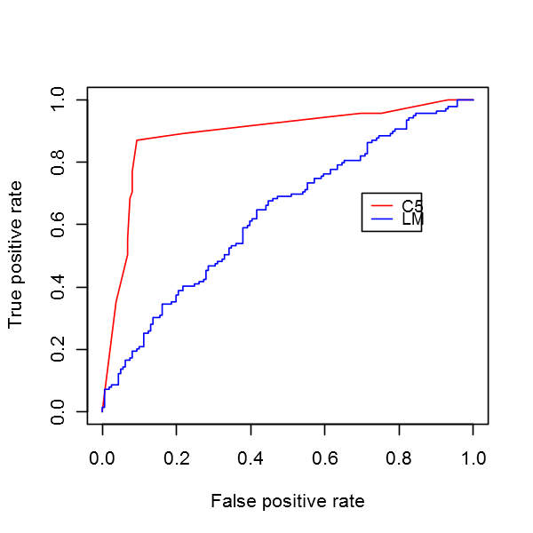

```r
options(repr.plot.width = 5, repr.plot.height=5)

c5_pred <- prediction(test$c5_pred_prob[, "YES"], test$pep)
c5_model.perf <- performance(c5_pred, "tpr", "fpr")

lm_pred <- prediction(test$lm_pred_prob, test$pep)
lm_model.perf <- performance(lm_pred, "tpr", "fpr")

plot(c5_model.perf, col="red")
plot(lm_model.perf, col="blue", add=T)
legend(0.7, 0.7, c("C5","LM"), cex=0.9, col=c("red", "blue"), lty=1)
```

- 그래프가 경사가 더 크고 급격하게 상승 후 마지막 정확도가 동일 한 경우
  - 동일 한 정확도를 가지고 있더라도 선택하는 Subset 즉, Choosing을 하게 될 사람 수가 적게 된다면  
    위의 빨깐 선보다 경사가 높은 경우를 선택하는 것이 좋다.

## Deployment

```r
newd$c5_pred <- predict(c5_model, newd, type="class")
newd$c5_pred_prob <- predict(c5_model, newd, type="prob")
target <- subset(newd, c5_pred=="YES" & c5_pred_prob[ ,"YES"] > 0.8)
head(target[order(target$c5_pred_prob[,"YES"], decreasing=T),])
# write.csv(target[order(target$c5_pred_prob[,"YES"], decreasing=T), ], "dm_target.csv", row.names=FALSE)
```

|  | id | age | sex | region | income | married | children | car | save_act | current_act | mortgage | c5_pred | c5_pred_prob |  |
| --- | --- | --- | --- | --- | --- | --- | --- | --- | --- | --- | --- | --- | --- | --- |
| 4 | ID12704 | 50 | MALE | TOWN | 46794.4 | YES | 2 | NO | YES | NO | YES | YES | 0.0520408187357896 | 0.94795918126421 |
| 16 | ID12716 | 44 | MALE | TOWN | 34961.7 | YES | 1 | NO | NO | NO | YES | YES | 0.0520408187357896 | 0.94795918126421 |
| 21 | ID12721 | 40 | MALE | TOWN | 37227.8 | NO | 1 | YES | YES | YES | NO | YES | 0.0520408187357896 | 0.94795918126421 |
| 23 | ID12723 | 54 | MALE | RURAL | 49986.7 | YES | 1 | YES | YES | YES | NO | YES | 0.0520408187357896 | 0.94795918126421 |
| 29 | ID12729 | 58 | MALE | RURAL | 41114.2 | YES | 2 | YES | YES | YES | YES | YES | 0.0520408187357896 | 0.94795918126421 |
| 43 | ID12743 | 66 | MALE | INNER_CITY | 43720.4 | NO | 1 | NO | YES | NO | YES | YES | 0.0520408187357896 | 0.94795918126421 |